# Chap4

202140191 엄태훈

2021-04-30(Fri)

# Chap4 Graphs

본격적으로 데이터를 분석하고 모델링을 진행하기에 앞서 데이터의 전처리는 가장 중요한 작업이다.  
전처리와 더불어 중요한 작업이 바로 *EDA(Exploratory Data Analysis, 탐색적 자료 분석)*이다.

복잡한 데이터를 접했을 때 평균, 표준편차, 상관관계 같은 수치적인 값 보다는 항상 시각적인 요소를 통해 데이터를 살펴보는 것이 중요하다.

이번 Chapter4의 내용을 통해 다양한 시각화 기법을 알아보자.

## What Is a Graph?

- pch: 포인트의 모양
- col: 색깔 지정
- legend: 범례 지정 (*범례로 쓰이는 변수의 범주의 수만큼 색깔, 포인트 모양을 지정해야 한다.*)  
  legend의 경우 x,y축을 통해 위치를 지정할 수도 있지만, `bottom`,`topleft`,`corner`등의 명령어를 사용하여 간편하게 지정할 수도 있다.

```r
library(HH)
```

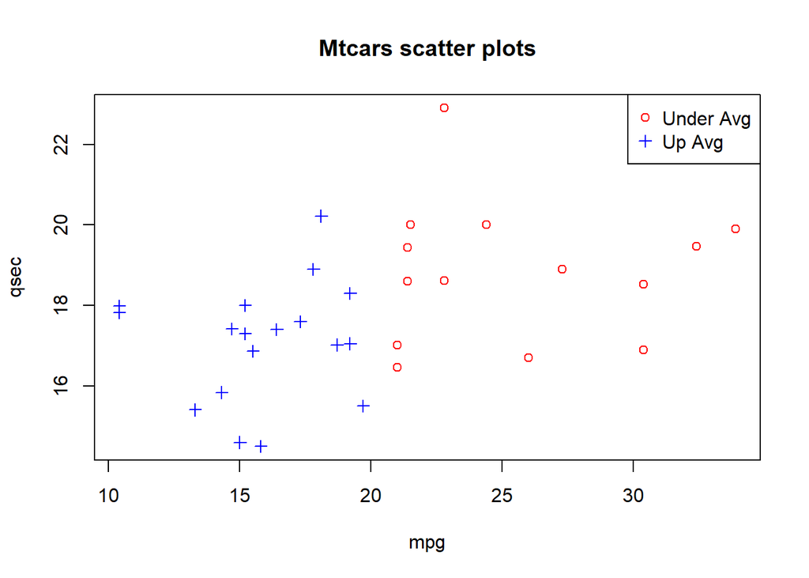

```r
data(mtcars)
# type="n"을 지정하면 비어있는 산점도를 그릴 수 있다.

plot(x=mtcars$mpg,y=mtcars$qsec,xlab="mpg",ylab="qsec",main="Mtcars scatter plots",type="n")
points(mtcars$mpg[mtcars$mpg<mean(mtcars$mpg)],mtcars$qsec[mtcars$mpg<mean(mtcars$mpg)],pch=3,col="blue")
points(mtcars$mpg[mtcars$mpg>=mean(mtcars$mpg)],mtcars$qsec[mtcars$mpg>=mean(mtcars$mpg)],pch=1,col="red")
legend("topright",legend=c("Under Avg","Up Avg"),pch=c(1,3),col=c("red","blue"))
```

#### R의 pch 옵션 종류

R은 다양한 pch 옵션을 제공하고 있는데 숫자별 옵션은 다음과 같다.

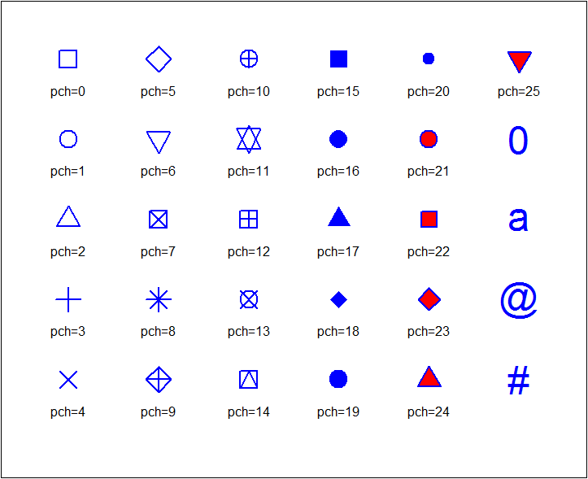

출처: (https://rvisuall.tistory.com/18)  
makhimh R 시각화 블로그

## xyplot(조건부 산점도 그래프) 이용

위에서는 plot을 이용하여 산점도를 그려보았다.  
R에서 제공하는 다양한 시각화 함수 중 xyplot을 이용해 그림을 그려보자.  
xyplot은 lattice 패키지의 내장된 함수로 lattice 패키지를 설치해야 사용이 가능하다. `install.pacakges("lattice")`  
xyplot은 plot 함수와 다르게 더 많은 옵션을 가지고 있고 조금 더 세심하고 부드럽게 그릴 수 있다.

- groups: 지정한 변수를 기준으로 그룹을 나눈다.
- auto.key: 범례의 위치를 알맞은 곳에 자동으로 생성한다. *(옵션을 TRUE로 지정할 경우)*

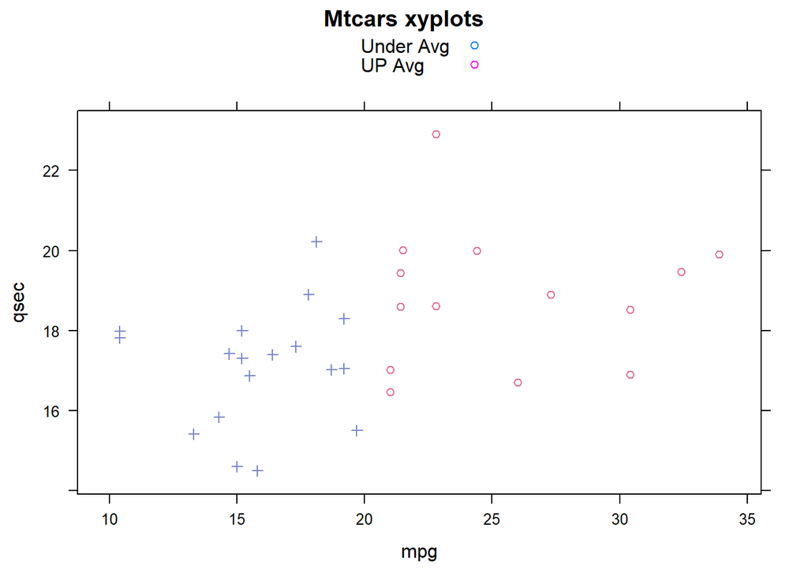

```r
library(lattice)

# 범례를 지정할 group 변수를 생성한다.
mtcars$lable <- ifelse(mtcars$mpg>=mean(mtcars$mpg),"UP Avg","Under Avg")

xyplot(mtcars$qsec~mtcars$mpg,main="Mtcars xyplots",
       xlab="mpg",ylab="qsec",pch=c(3,1),col=c("#7685C8","#E16A92"),groups=mtcars$lable,
       auto.key=TRUE)
```

Auto.key를 사용하지 않고 Key를 통해 직접 범례를 만들 수 있다.  
`key=list((x,y,corner=(...),text=list(...),points=list(pch=...,col=...)))`

- (x,y,corner): 범례의 위치를 직접 지정한다.
- text=list(…): 범례에 들어갈 텍스트를 지정한다.
- points: 범례를 표시할 포인트의 종류, 색깔을 지정한다.

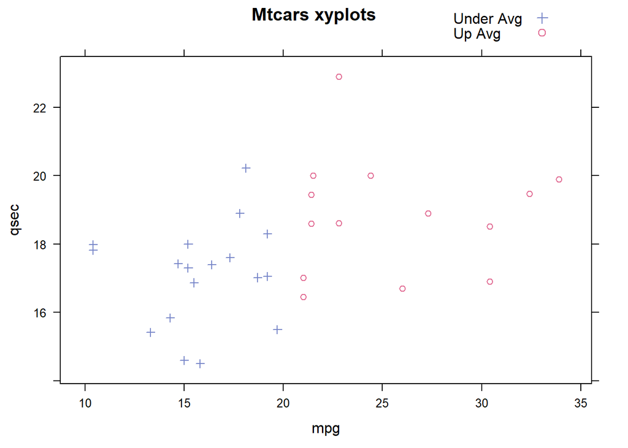

```r
xyplot(mtcars$qsec~mtcars$mpg,main="Mtcars xyplots",
       xlab="mpg",ylab="qsec",pch=c(3,1),col=c("#7685C8","#E16A92"),groups=mtcars$lable,
       key=list(x=0.95,y=1.05,corner=c(1.1,0),
         text=list(c("Under Avg","Up Avg")),
            points=list(pch=c(3,1),col=c("#7685C8","#E16A92"))))
```

key를 통해 직접 지정한 위치에 범례가 표시된 것을 확인할 수 있다.

## 4.4 Scatterplot Matrix

xyplot(조건부 산점도 그래프)는 지정한 조건에 따라 plot을 분리하여 그릴 수 있다.  
`xyplot(formula | condition...)`에서 `condition`부분에 변수를 넣어주면 지정한 변수에 따라 plot을 분리한다.  
`layout`은 subplot들의 행과 열을 지정해준다.

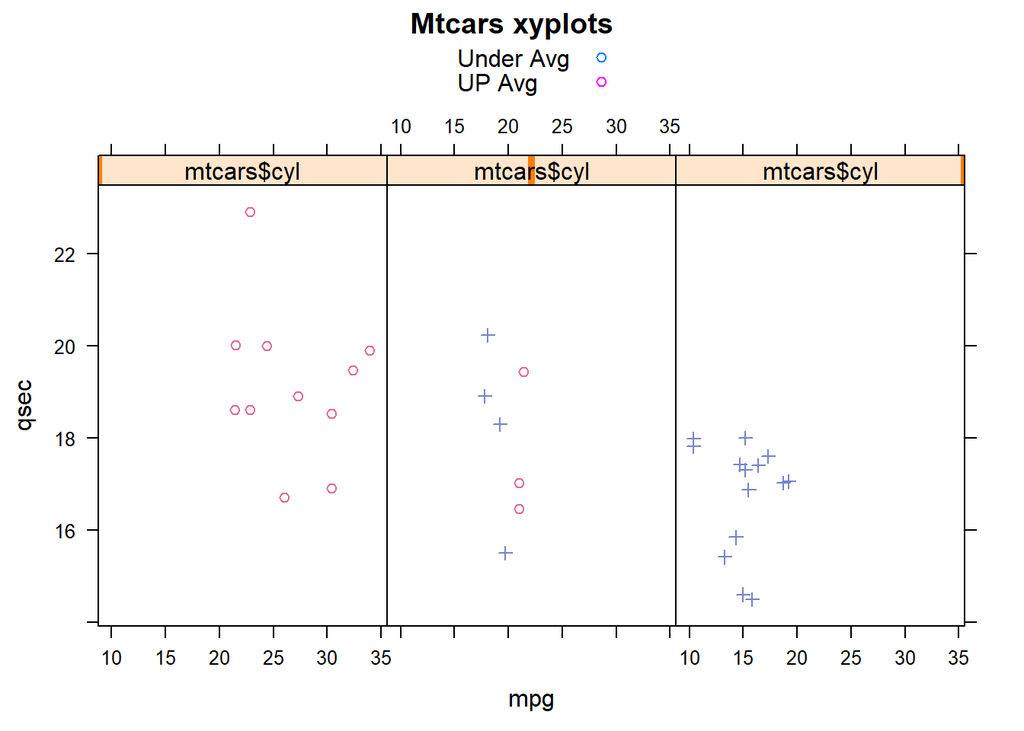

```r
xyplot(mtcars$qsec~mtcars$mpg|mtcars$cyl,main="Mtcars xyplots",
       xlab="mpg",ylab="qsec",pch=c(3,1),col=c("#7685C8","#E16A92"),groups=mtcars$lable,
       auto.key=TRUE)
```

조건부를 이용하여 실린더의 갯수에 따라 그래프를 그려주었다.

맨 왼쪽의 경우가 cyl=4, 가운데 패널이 cyl=6, 오른쪽 패널이 cyl = 8인 경우이다.

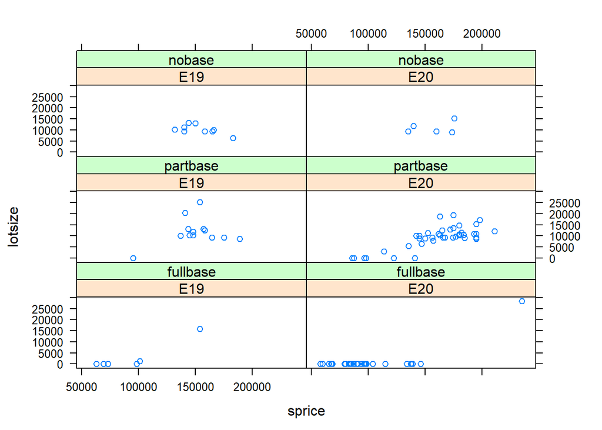

```r
# factor 변수의 범주가 문자형인 경우
data(njgolf)
xyplot(lotsize~sprice|grid*basemtf,data=njgolf)
```

가능한 모든 조건에 대한 plot을 그려준다.

## 다차원 산점도 행렬

R에서 다차원 데이터의 산점도를 비교하는 경우 Pairs함수를 통해 그릴 수 있다.  
Pairs 함수는 내장함수이기 때문에 따로 패키지 설치가 필요하지 않다.  
아래와 같이 간단한 formula를 적어주면 그릴 수 있다.

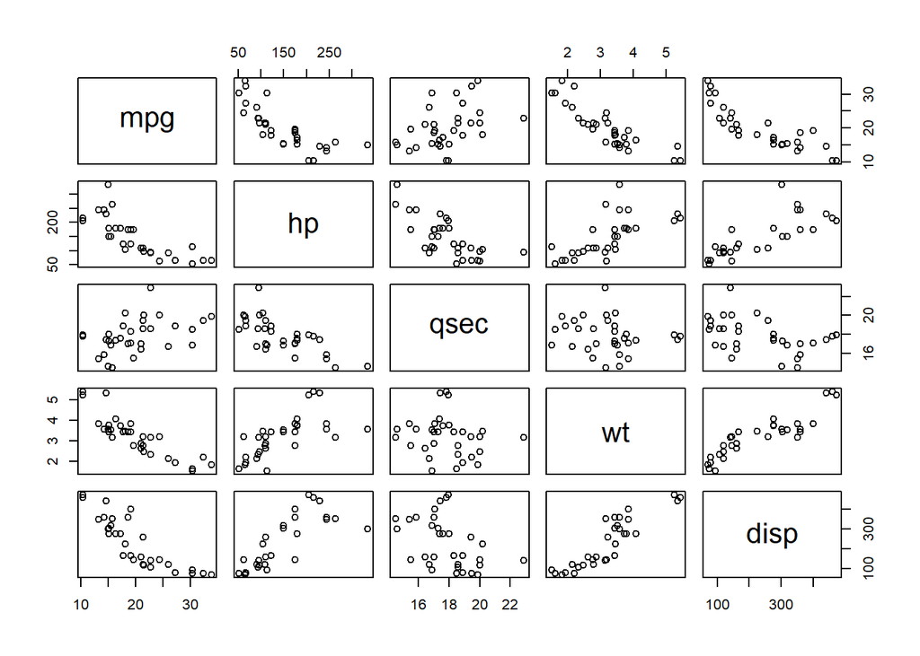

```r
pairs(~mpg+hp+qsec+wt+disp,data=mtcars)
```

lattice 패키지의 `splom`함수를 이용하면 조건부 산점도 행렬 그래프를 그릴 수 있다.  
xyplot과 같이 조건에 따라 plot을 분리해주는 역할을 하기도한다.

```r
library(dplyr)
df <- iris %>%
  select(Sepal.Width,Sepal.Length,Petal.Length,Petal.Width)
```

`splom`의 경우 xyplot 함수와 사용이 거의 비슷하다.  
산점도 행렬을 그릴 formula를 지정해주고 그룹, 색깔 등 부가적인 옵션을 지정해주면 된다.

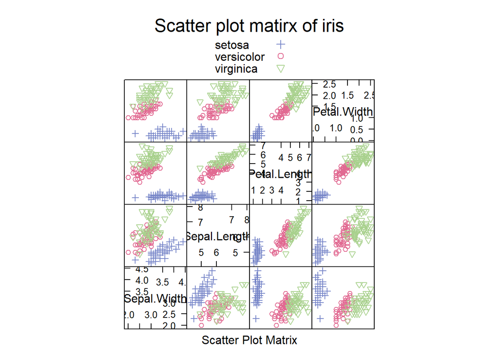

```r
splom(~df,pch=c(3,1,6),col=c("#7685C8","#E16A92","#A9D18E"),groups=iris$Species,
      key=list(title="Scatter plot matirx of iris",
               text=list(c("setosa","versicolor","virginica")),
               points=list(pch=c(3,1,6),col=c("#7685C8","#E16A92","#A9D18E"))))
```

pairs 함수에 비해서 축이 더 세밀한 것을 알 수 있고 조금 더 부드럽게 그려지는 것을 확인할 수 있다.

### split을 통한 subplot 그리기

`gridExtra` 패키지를 이용하지 않고 print의 `split`,`more`을 통해 여러 개의 plot을 그릴 수 있다.  
`print(plot을 저장한 객체,split=c(a,b,c,d),more)` split을 통해 subplot을 나누고 more을 통해 subplot을 더 그릴 것인지 확인한다.  
- a,b: plot을 그릴 행,열을 지정한다.  
- c,d: subplot을 그릴 행,열(차원) 생성한다.  
more: subplot을 더 그려야하면 TRUE, 마지막 plot이면 FALSE로 지정한다.

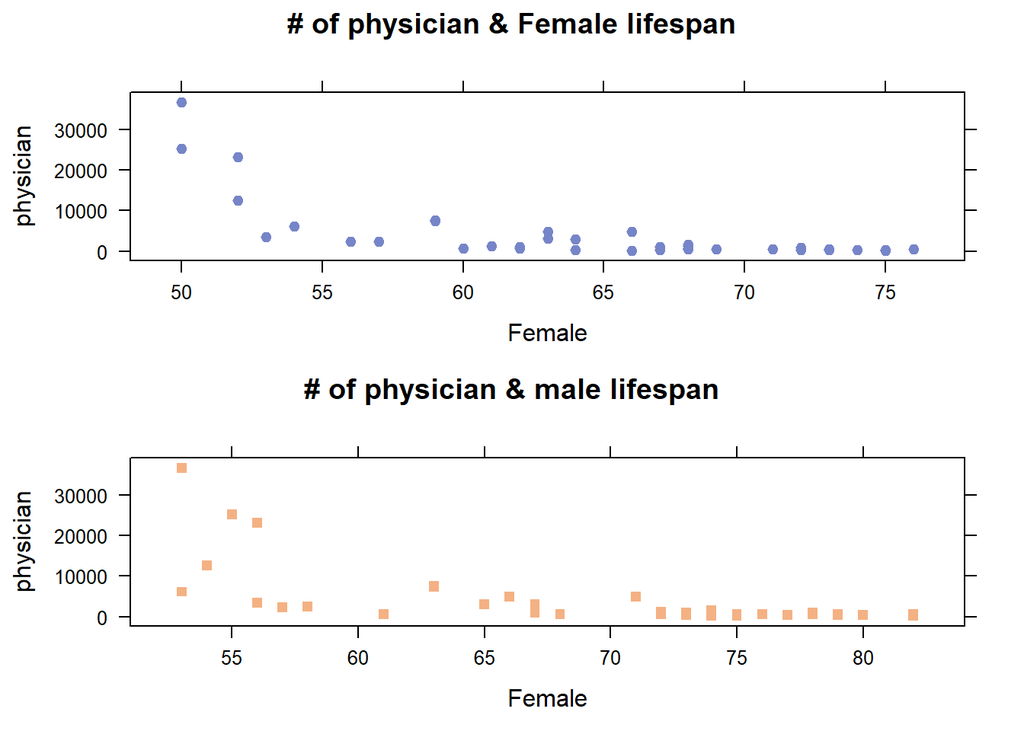

```r
data(tv)
p1<-xyplot(ppl.per.phys~male.life.exp,data=tv,
       pch=19,col="#7685C8",
       ylab="physician",xlab="Female",main="# of physician & Female lifespan")
p2<-xyplot(ppl.per.phys~fem.life.exp,data=tv,
           pch=15,col="#F4B183",
           ylab="physician",xlab="Female",main="# of physician & male lifespan")

print(p1,split=c(1,1,1,2),more=TRUE)
print(p2,split=c(1,2,1,2),more=FALSE)
```

## Data Transformations

종종 plot을 그리다 보면 특정 데이터들의 패턴이 비슷하거나 관찰이 어려운 경우가 있다.

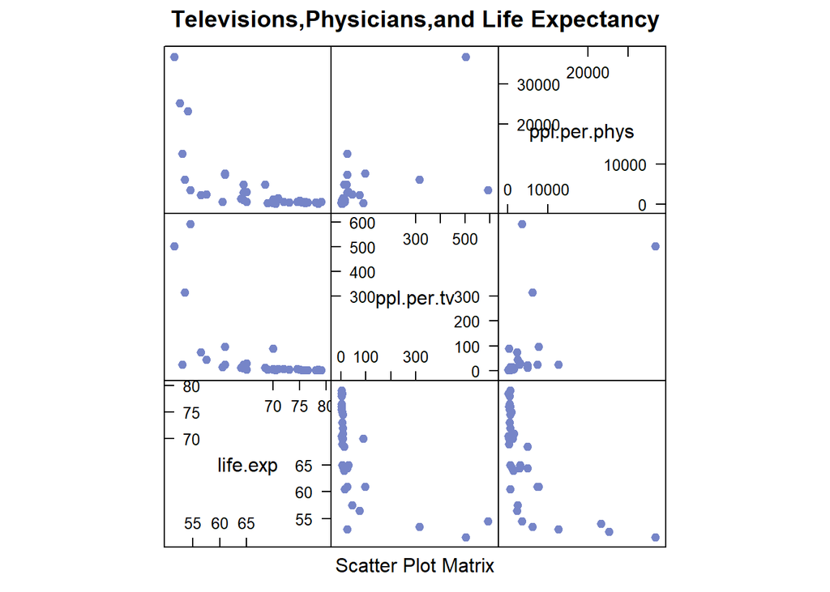

```r
df2 <- tv %>%
  select(life.exp,ppl.per.tv,ppl.per.phys)
splom(~df2,pch=19,col="#7685C8",main="Televisions,Physicians,and Life Expectancy")
```

tv 데이터의 경우 ppl.per.phys, ppl.per.tv 데이터의 산점도 행렬이 L자 형태로 상당히 비슷하고 패턴 관찰이 어려운 것을 확인할 수 있다.  
이러한 경우 log를 취하게 되면 관찰이 어려운 데이터를 조금 더 자세히 볼 수 있고 패턴이 비슷한 데이터 들의 문제를 해결할 수 있다.

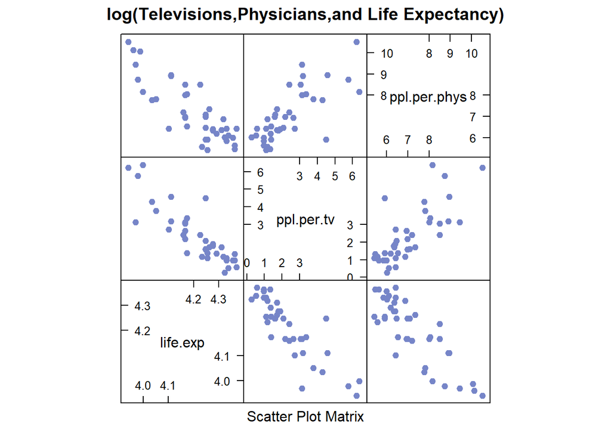

```r
splom(~log(df2),pch=19,col="#7685C8",main="log(Televisions,Physicians,and Life Expectancy)")
```

log를 취하고 그래프를 그린 결과, 기존에 그린 산점도 행렬보다 조금 패턴을 보기 쉽게 변한 것을 확인할 수 있다.

## Life Expectancy Example-Continued

lattice 패캐지 안에는 boxplot을 그릴 수 있는 `bwplot` 함수가 포함돼 있다.  
`bwplot`은 기본 `boxplot`함수 보다 더 부드러운 *boxplot*을 그릴 수 있는 장점이 있다.  
`Formula`의 형태로 bwplot을 진행하면 범주형 변수에 따라 데이터를 나눠서 boxplot을 그려준다.

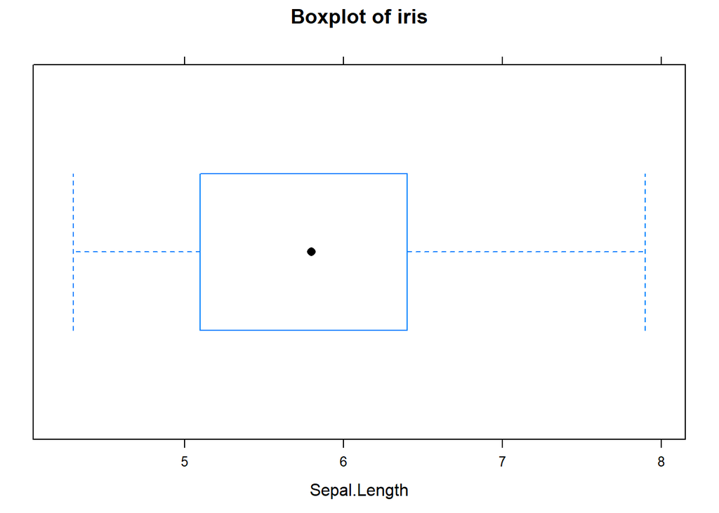

```r
# Bwplot
data(iris)

# Sepal.Length에 대한 boxplot을 출력해준다.
bwplot(iris$Sepal.Length,xlab = "Sepal.Length" ,main = "Boxplot of iris")
```

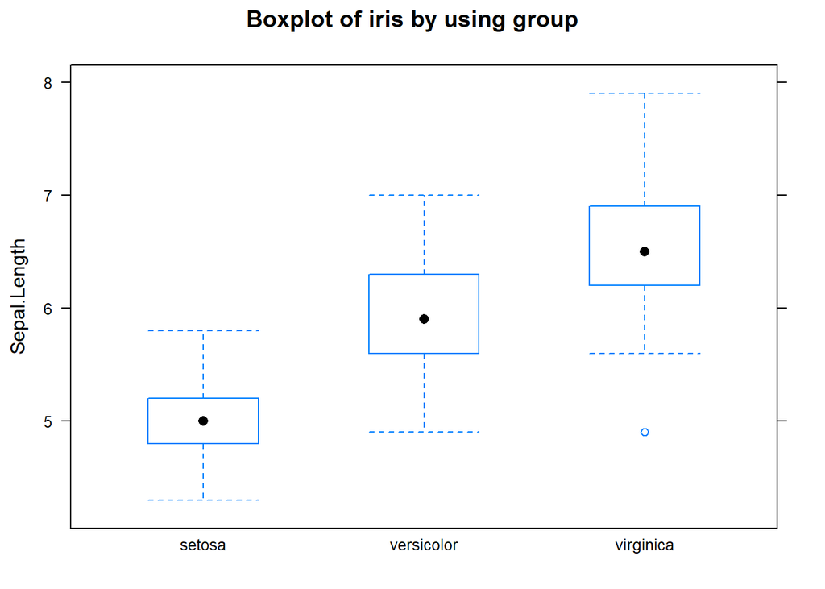

```r
bwplot(Sepal.Length~Species,data=iris,main = "Boxplot of iris by using group")
```

```r
iris$class <- ifelse(iris$Sepal.Length>mean(iris$Sepal.Length),"High","LOW")
```

Formula 뒤에 |을 이용하여 조건 변수를 넣어주면 조건 변수에 따라 boxplot을 구분하여 그릴 수 있다.

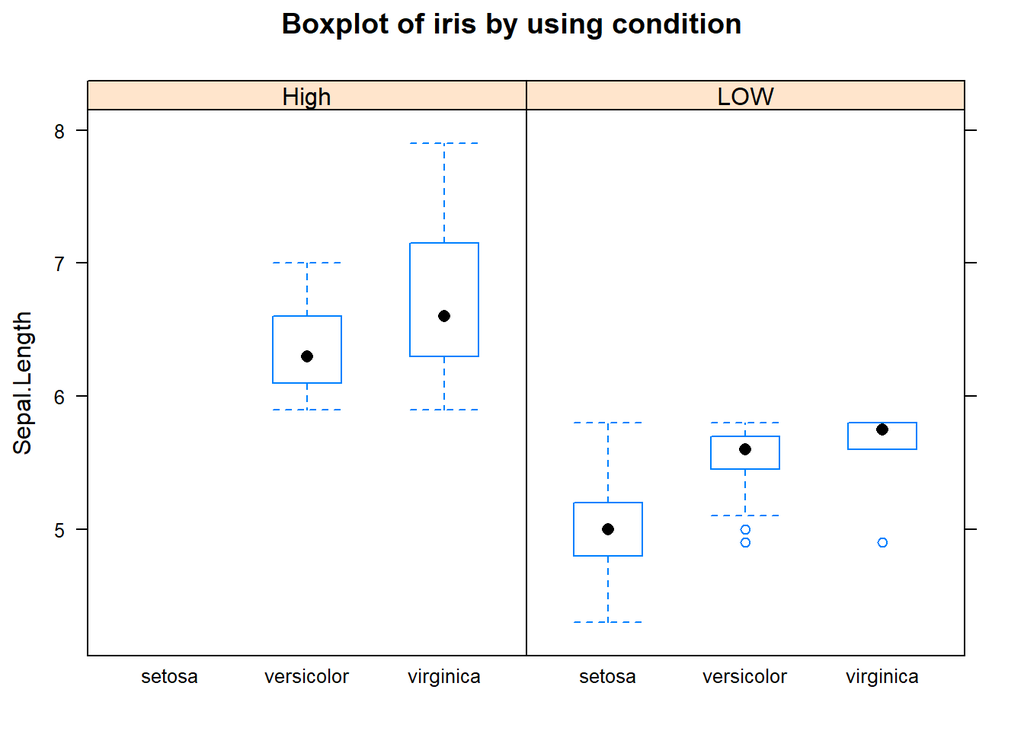

```r
bwplot(Sepal.Length~Species|class,data=iris,main = "Boxplot of iris by using condition")
```

`stripplot`은 1차원 산점도를 그리는 함수로, sample size가 작을 때 boxplot을 대신하기 좋다.  
lattice 패키지는 stripplot 또한 제공하며 함수의 구조는 앞선 xyplot, bwplot과 유사하다.  
`Formula`의 형태로 stripplot을 진행하면 범주형 변수에 따라 데이터를 나눠서 stripplot을 그려준다.

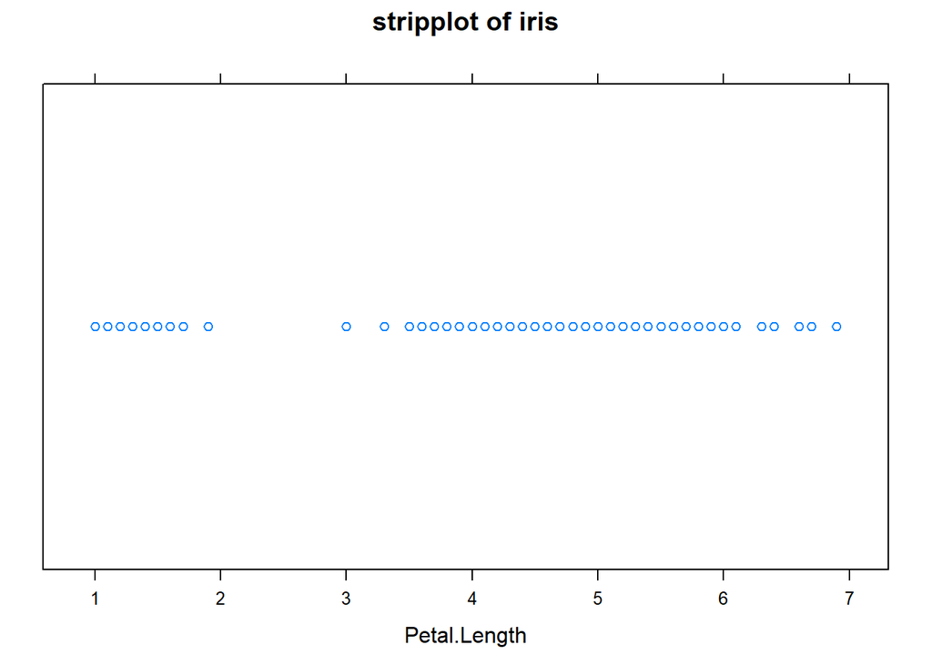

```r
stripplot(iris$Petal.Length,xlab = "Petal.Length",main = "stripplot of iris")
```

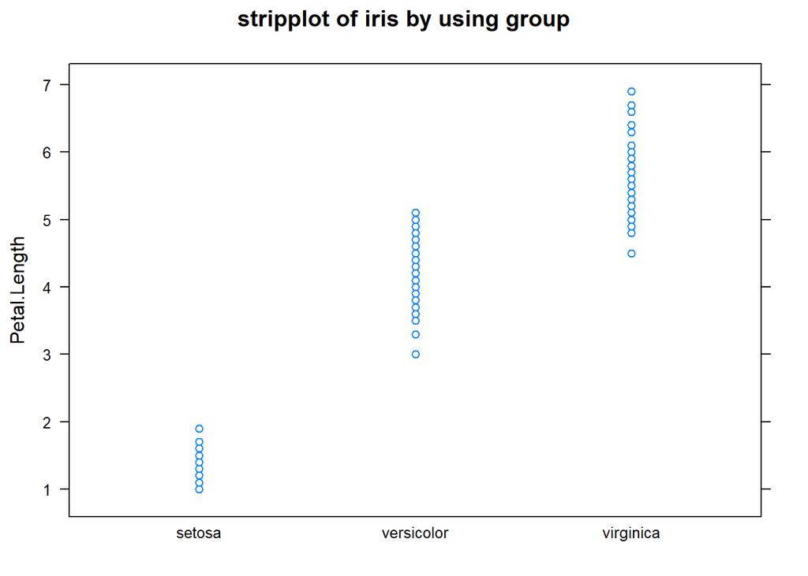

```r
stripplot(Petal.Length~Species,data=iris,main = "stripplot of iris by using group")
```

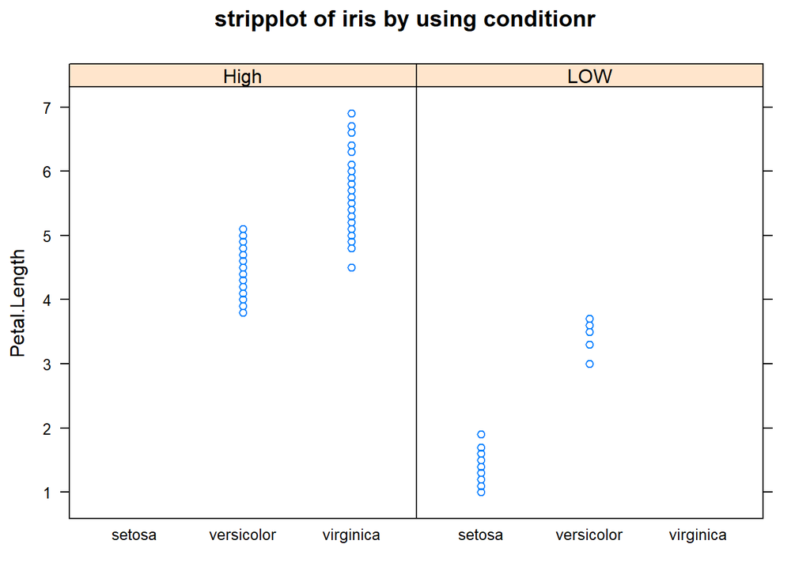

```r
iris$class2 <- ifelse(iris$Petal.Length>mean(iris$Petal.Length),"High","LOW")
# Formula 뒤에 조건 변수를 넣어주면 조건 변수에 따라 stripplot을 구분하여 그릴 수 있다.
stripplot(Petal.Length~Species|class2,data=iris,main = "stripplot of iris by using conditionr")
```

## Radar chart

다변량 데이터를 사용하는 경우 시각화에 대한 어려움이 존재할 수 있다.  
특히, 우리가 배웠던 히스토그램, 산점도, 박스그림으로 나타내는데에는 한계가 존재한다.  
*Radar Chart*는 이러한 다변량 데이터를 효과적으로 시각화할 수 있는 방법 중 하나이다.

```r
library(doBy)
library(vcd)
```

```r
data(Hitters)
# 내야수에 대한 Radar Chart를 그리기 위해 OF와 UT는 제거하였다.

Rader_dat <- Hitters %>%
  filter(Positions!="OF" & Positions!="UT")
```

*Radar Chart*에서는 데이터의 평균을 통한 그림을 그릴 것이므로 *doBy*패키지의 *summaryBy* 함수를 사용한다.

```r
position_mean <- summaryBy(Putouts+Assists+Errors~Positions,data=Rader_dat,FUN=c(mean))
position_mean
```

```
##   Positions Putouts.mean Assists.mean Errors.mean
## 1        1B   0.71975286    0.1858316   0.3464506
## 2        2B   0.18493489    0.7394621   0.4326132
## 3        3B   0.06216235    0.4482803   0.5604424
## 4         C   0.39465913    0.1020990   0.2826646
## 5        SS   0.14137337    0.7014459   0.6458333
```

*Radar chart*를 그리기 위해서는 1번째 행은 열에 대한 최대값, 2번째 행은 열에 대한 최솟값을 놓아야 한다.  
따라서, rader_df라는 함수를 통해 조건에 맞는 데이터 변환과정을 진행할 수 있도록 하였다.

```r
library(fmsb)
rader_df <- function(df){
  df <- data.frame(df)
  dfmax <- apply(df,2,max)
  dfmin <- apply(df,2,min)
  as.data.frame(rbind(dfmax,dfmin,df))
}

Rader_dat <- rader_df(position_mean[,c(2:4)])
Rader_dat
```

```
##   Putouts.mean Assists.mean Errors.mean
## 1   0.71975286    0.7394621   0.6458333
## 2   0.06216235    0.1020990   0.2826646
## 3   0.71975286    0.1858316   0.3464506
## 4   0.18493489    0.7394621   0.4326132
## 5   0.06216235    0.4482803   0.5604424
## 6   0.39465913    0.1020990   0.2826646
## 7   0.14137337    0.7014459   0.6458333
```

원하는대로 데이터 구조가 변환된 것을 확인할 수 있다.

`radarchart(데이터,seg,plty,title)`을 통해 radar chart를 그린다.  
- *데이터*: radar chart에 맞게 데이터 구조가 변환된 데이터를 넣어준다.  
- *seg*: 요약된 변수들의 갯수  
- *plty*: 선의 모양 - *title*: radarchart의 제목

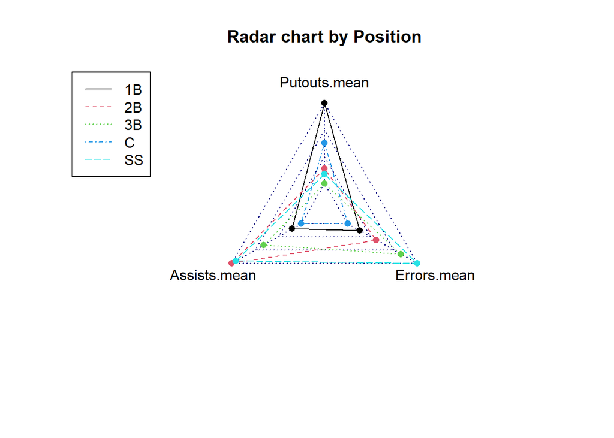

```r
radarchart(Rader_dat,
           seg=3,
           plty=1:5,
           title=c("Radar chart by Position"))
legend("topleft",legend = position_mean$Positions,col=c(1:5),lty=c(1:5))
```

radarchart를 위와 같이 그릴 수 있다.  
변수를 3가지만 요약해서 사용했기 때문에 오각형이 아닌 삼각형의 모양을 띄고있다.  
유격수의 경우 수비 부담이 큰 포지션이기 때문에 그에따라 에러의 평균이 높은 것을 살펴볼 수 있다.

### 오각형의 radarchart

다음은, Cars93데이터를 이용해 오각형의 radarchart를 그리는 코드이다.

```r
library(MASS)
data(Cars93)
Cars93_mean <- summaryBy(Min.Price + Max.Price + RPM + Length + Width ~ Type,data=Cars93,
                         FUN = c(mean))

Rader_data_car <- rader_df(scale(Cars93_mean[,c(2:6)]))
Rader_data_car
```

```
##    Min.Price.mean Max.Price.mean   RPM.mean Length.mean Width.mean
## 1       1.1886786     1.34618516  1.1399576  1.53293142  1.3084428
## 2      -1.5767231    -1.67136671 -1.3321490 -1.31904165 -1.3429204
## 11     -0.2958143    -0.22556805  0.4429717 -0.18708691 -0.7913129
## 21      0.9811161     0.58545511 -1.3321490  1.53293142  1.3084428
## 3       1.1886786     1.34618516  0.3757101  0.60272622  0.1596403
## 4      -1.5767231    -1.67136671  1.1399576 -1.31904165 -1.3429204
## 5      -0.0906989    -0.02359726  0.5210954 -0.71088103 -0.2196469
## 6      -0.2065584    -0.01110825 -1.1475858  0.08135194  0.8857970
```

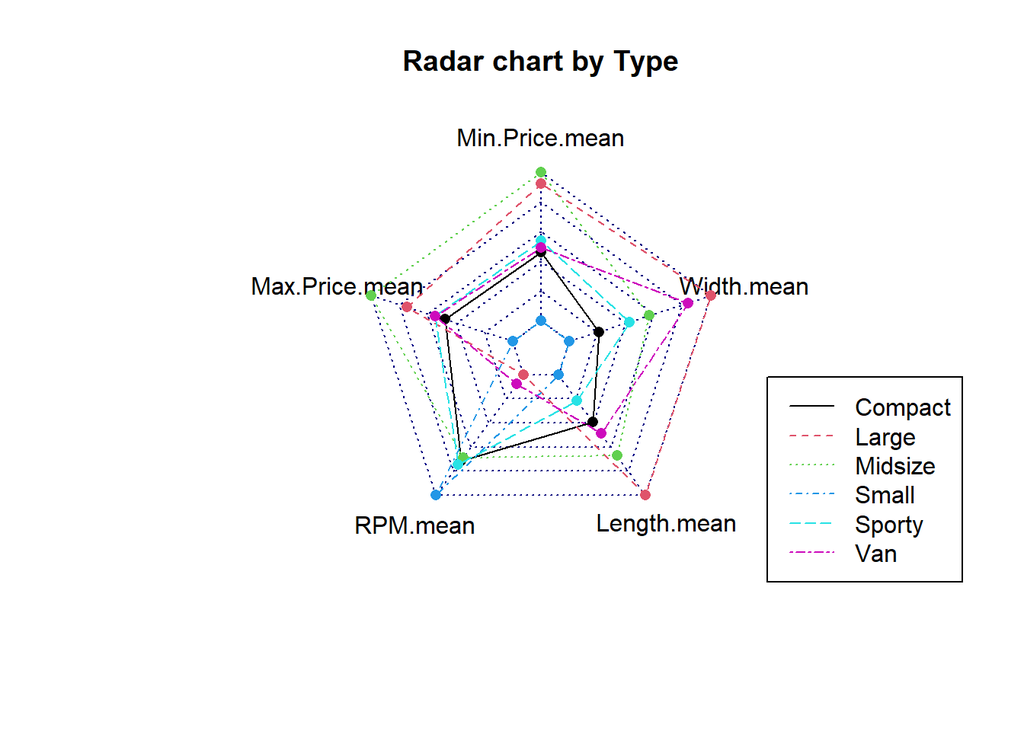

```r
radarchart(Rader_data_car,
           seg=5,
           plty=1:6,
           title=c("Radar chart by Type"))
legend("bottomright",legend = Cars93_mean$Type,col=c(1:6),lty=c(1:6))
```

Type이 Large인 경우 차의 폭과 너비의 평균이 제일 높은 것을 알 수 있다.

## Lollipop chart

Lollipop chart는 막대 그래프의 변형으로 보다 더 좋은 가독성을 가진다.  
막대그래프 대신 막대 사탕의 모양을 가지고 있어서 Lollipop chart라는 이름을 가지고 있다.

*Lollipop chart*는 `ggplot2`의 `geom_segment`를 이용하여 그릴 수 있다.

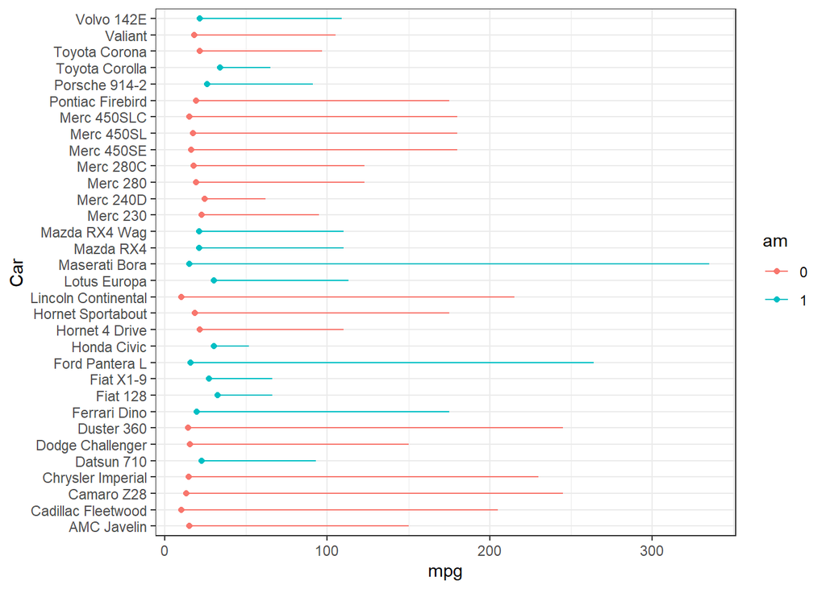

```r
library(ggplot2)
data(mtcars)
mtcars$am <- as.factor(mtcars$am)

ggplot(mtcars,aes(mpg,rownames(mtcars),col=am))+
  geom_segment(aes(hp,y=rownames(mtcars),xend=mpg,yend=rownames(mtcars)))+
  ylab("Car")+
  geom_point()+
  theme_bw()
```

## Parallel coordinate plot

평행좌표그림은 선 그래프 형태로 다변량에 대한 시각화를 진행할 수 있는 그래프이다.

```r
library(doBy)
data("Hitters")

# 내야수에 대한 Radar Chart를 그리기 위해 OF와 UT는 제거하였다.

dat <- Hitters %>%
  filter(Hitters$Positions!="OF" & Hitters$Positions!="UT")

unique(dat$Positions)
```

```
## [1] 1B 2B 3B C  SS
## Levels: 1B 2B 3B C OF SS UT
```

```r
dat$Position_Type <- ifelse(dat$Positions=="1B",1,
                            ifelse(dat$Positions=="2B",2,
                                   ifelse(dat$Positions=="3B",3,
                                          ifelse(dat$Positions=="C",4,5))))
```

데이터는 *Hitters*데이터를 사용하였는데, 포지션별로 선 모양과 선 색깔을 다르게 하기 위해서 전처리를 진행하였다.

평행좌표그림은 R의 *MASS* `parcoord`함수를 이용하여 그림을 그릴 수 있다.  
함수의 입력은 다음과 같다.  
`parcoord(data,lty,col,var.label,main)`  
- *data*: 평행좌표그림을 그릴 데이터 - *lty*: 선의 모양  
- *col*: 선의 색깔  
- *var.label=TRUE*: 각 컬럼의 최댓값 최솟값을 표시한다.  
- *main*: 제목을 설정한다.

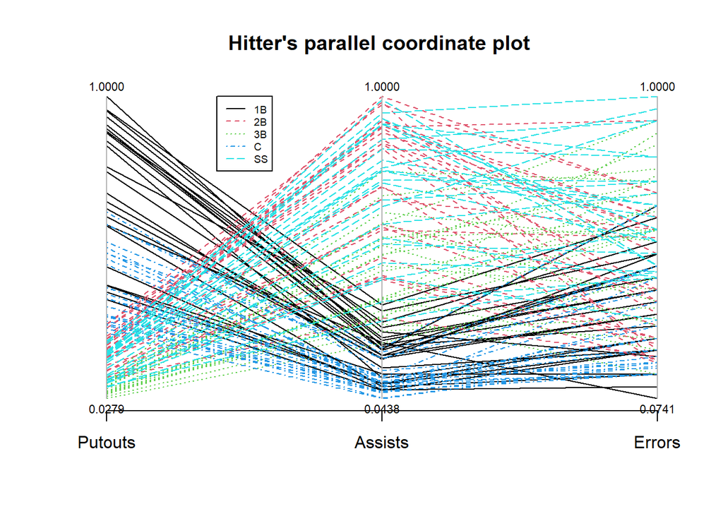

```r
library(MASS)
parcoord(dat[,c("Putouts","Assists","Errors")],
         lty=dat$Position_Type,
         col=dat$Position_Type,
         var.label=TRUE,
         main = "Hitter's parallel coordinate plot ")

legend(1.4,1,legend=c("1B","2B","3B","C","SS"),
       lty=c(1:5),
       col=c(1:5),
       cex=0.6)
```

## 3차원 산점도 (3 dimensional scatter plot)

3차원 산점도는 2차원에서 차원을 더 넓혀 3차원에 표현할 수 있는 산점도이다.  
`scatterplot3d`패키지의 `scatteplot3d`함수를 이용하여 시각화를 할 수 있다.

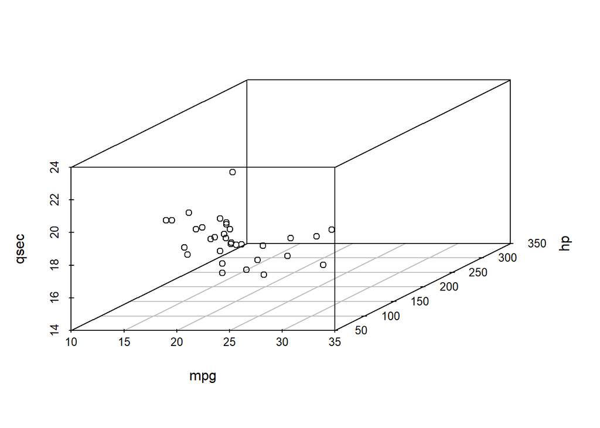

```r
library(scatterplot3d)
scatterplot3d(mtcars$mpg,mtcars$hp,mtcars$qsec,xlab="mpg",ylab="hp",zlab="qsec")
```

단순히 점이 나열돼있는 것만으로는 시각화가 약간은 부족해 보인다.

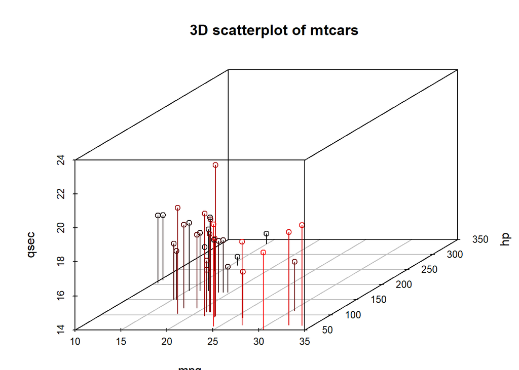

```r
library(scatterplot3d)
scatterplot3d(mtcars$mpg,mtcars$hp,mtcars$qsec,type="h",xlab="mpg",ylab="hp",zlab="qsec",highlight.3d = TRUE,
              mar=c(2,4,4,2),main="3D scatterplot of mtcars")
```

point만 놓여있는 것에 비해서 조금 더 상대적으로 크기가 잘보이는 것을 확인할 수 있다.